# Лабораторная работа №2

Исследование протокола TCP и алгоритма управления очередью RED

Шубнякова Дарья НКНбд-01-22

1132226452@pfur.ru

Российский университет дружбы народов

# Вводная часть

## Цели и задачи

- Исследовать протокол TCP и алгоритм управления очередью RED. Требуется разработать сценарий, реализующий модель, построить в Xgraph график изменения TCP-окна, график изменения длины очереди и средней длины очереди. – Изменить в модели на узле s1 тип протокола TCP с Reno на NewReno, затем на Vegas. Сравните и поясните результаты. – Внести изменения при отображении окон с графиками (измените цвет фона, цвет траекторий, подписи к осям, подпись траектории в легенде).

# Основная часть

## Выполнение лабораторной работы

Создаем нужную нам модель с дуплексными узлами. Берем алгоритм из лабораторной работы.

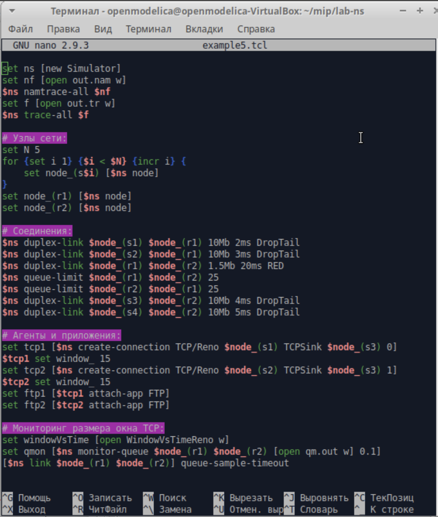

Создание модели

## Вот так будет выглядеть процедура финиш.

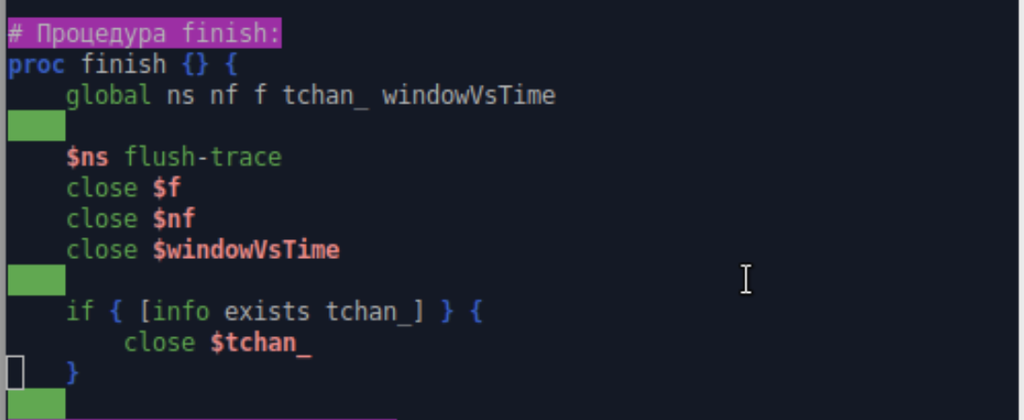

Процедура

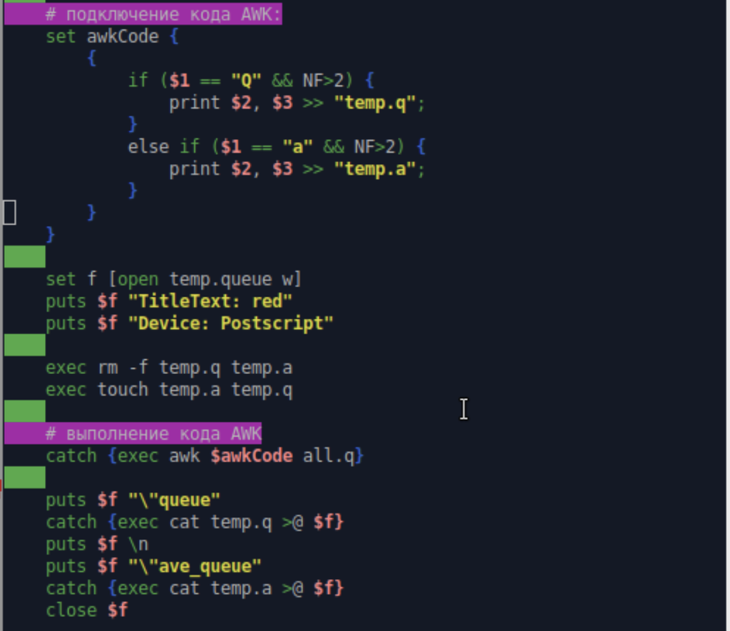

## И пишем часть для отображения графиков в Xgraph.

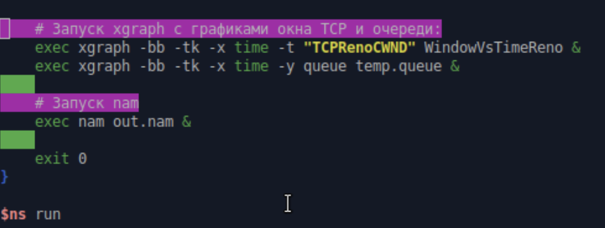

Отображение графиков

## Так будет выглядеть график динамики размера окна TCP Reno.

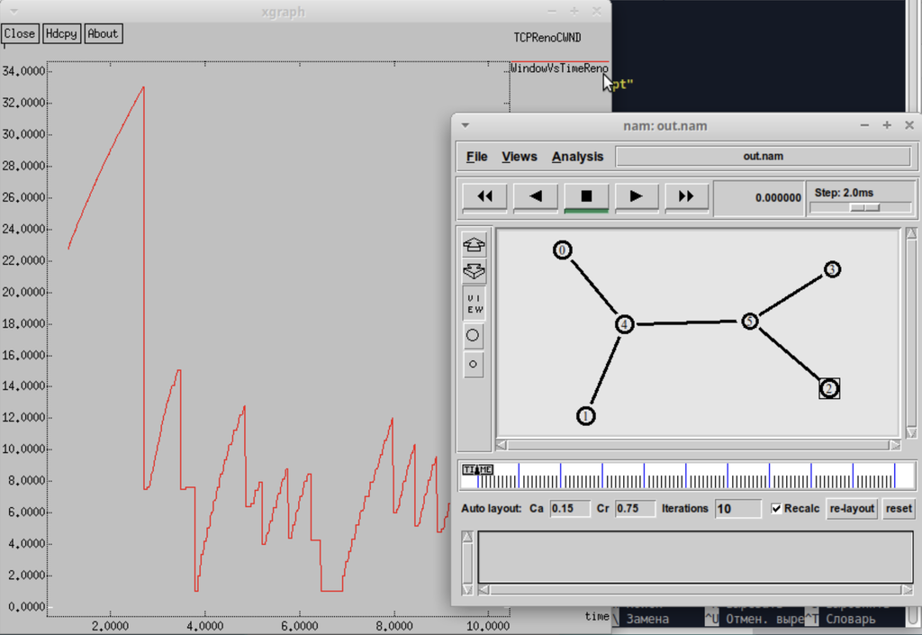

График динамики размера окна TCP Reno

## А здесь мы видим график динамики длины очереди и средней длины очереди.

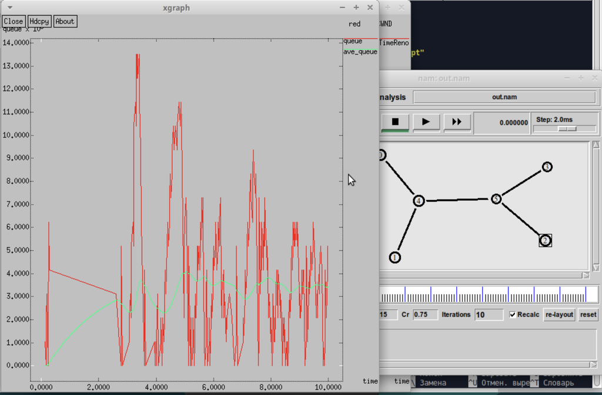

График очередей

## Меняем на алгоритм NewReno, важно соблюдать именно такое написание, как на скриншоте.

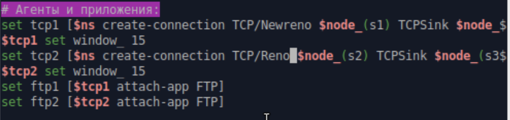

TCP NewReno

## Меняем цвет линий графика, фон графика, слегка меняем подписи осей, легенду и названия окон, чтобы показать освоение навыков в Xgraph.

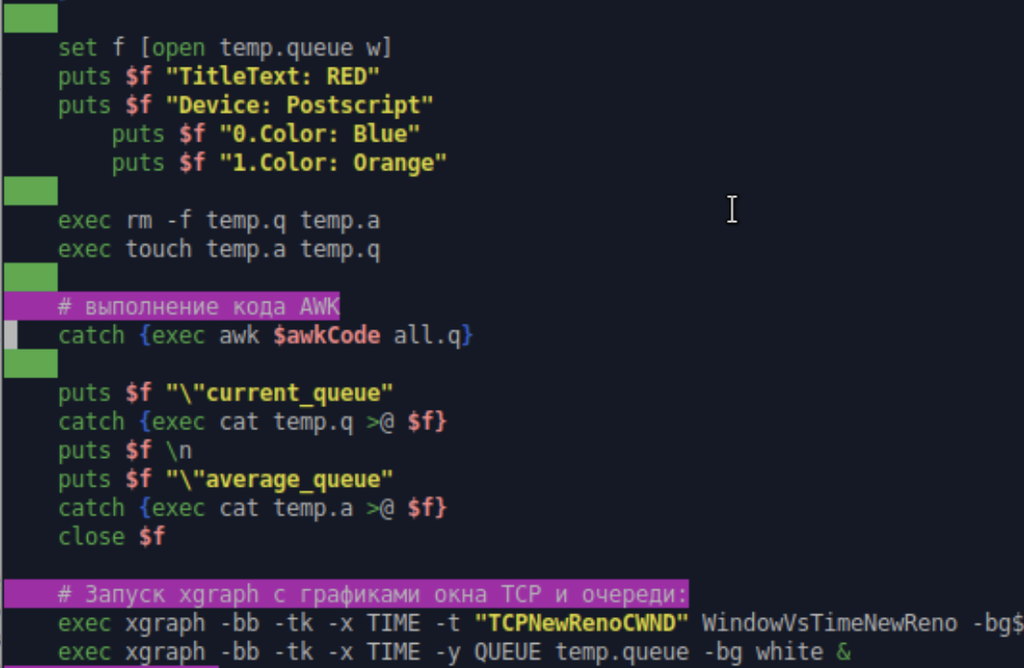

Изменения

## Меняем так же цвет линии в графике динамики размера окна TCP.

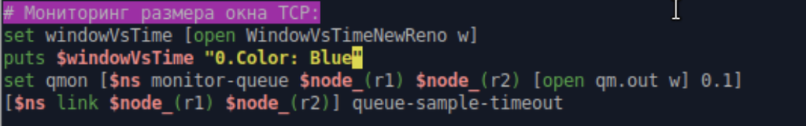

Изменения

## Видим, что все изменения были применены, и оцениваем график TCP NewReno.

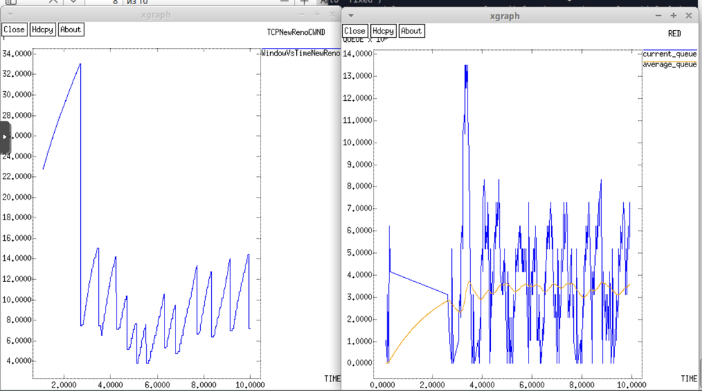

Графики для TCP NewReno

## Меняем цвет линии на графике динамики размера окна TCP и на первом узле ставим TCP Vegas.

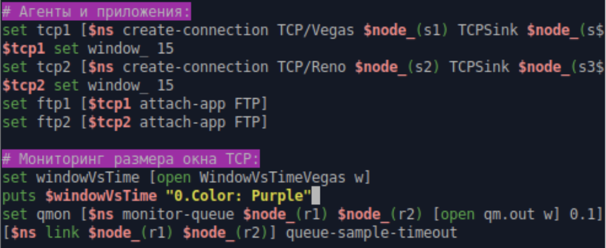

Изменения

## И меняем тайтлы и цвета для графика средней и текущей очередей.

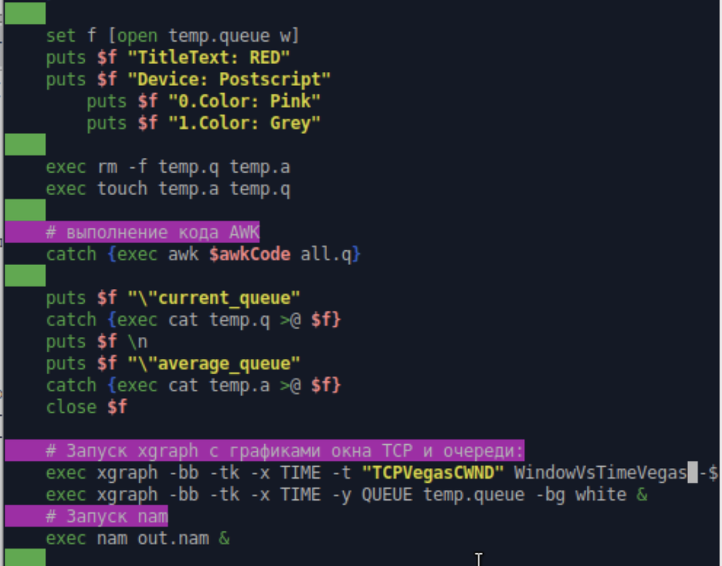

Изменения

## Оцениваем работу при TCP Vegas.

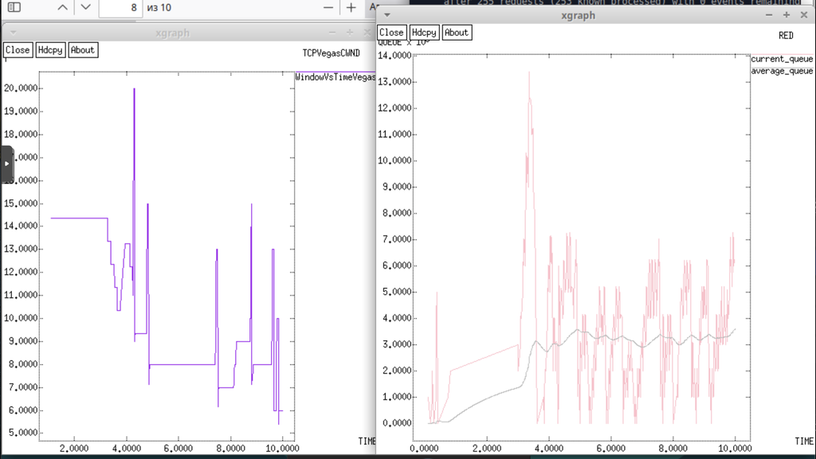

Графики TCP Vegas

# Результаты

Графики динамики размера окна у Reno и NewReno довольно похожи, второй действует чуть более плавно и нет таких сильных разбросов на протяжении работы. График динамики размера окна TCP Vegas очень ступенчатый, перепады резкие, нет плавных линий. В сети с RED очередью: - Reno: постоянно “прощупывает” пределы пропускной способности - Vegas: находит оптимальный уровень и держится near него - При изменении условий Vegas делает шаг к новому оптимальному уровню

# Результаты